# Binary-Class Tabular Model for Kaggle Playground Series Season 3 Episode 7 Using Python and Scikit-Learn

### March 20, 2023

SUMMARY: The project aims to construct a predictive model using various machine learning algorithms and document the end-to-end steps using a template. The Kaggle Playground Series Season 3 Episode 7 dataset is a binary-class modeling situation where we attempt to predict one of two possible outcomes.

INTRODUCTION: Kaggle wants to provide an approachable environment for relatively new people in their data science journey. Since January 2021, they have hosted playground-style competitions to give the Kaggle community a variety of reasonably lightweight challenges that can be used to learn and sharpen skills in different aspects of machine learning and data science. The dataset for this competition was generated from a deep learning model trained on the Reservation Cancellation Prediction dataset. Feature distributions are close to but different from the original.

ANALYSIS: The average performance of the machine learning algorithms achieved a ROC/AUC benchmark of 0.8470 after training. Furthermore, we selected Random Forest as the final model as it processed the training dataset with a ROC/AUC score of 0.8891. When we processed the test dataset with the final model, the model achieved a ROC/AUC score of 0.8716.

CONCLUSION: In this iteration, the Random Forest model appeared to be a suitable algorithm for modeling this dataset.

Dataset Used: Playground Series Season 3, Episode 7

Dataset ML Model: Binary-Class classification with numerical features

Dataset Reference: https://www.kaggle.com/competitions/playground-series-s3e7

One source of potential performance benchmarks: https://www.kaggle.com/competitions/playground-series-s3e7/leaderboard

## Task 1 - Prepare Environment

```python
# Retrieve the CPU information
ncpu = !nproc
print("The number of available CPUs is:", ncpu[0])
```

```
The number of available CPUs is: 4
```

### 1.a) Load libraries and modules

```python
# Set the random seed number for reproducible results
RNG_SEED = 888
```

```python
import numpy as np
import pandas as pd
import seaborn as sns
import matplotlib.pyplot as plt
import os
import sys
import math
# import boto3
import zipfile
import urllib
from datetime import datetime
from sklearn import preprocessing
from sklearn.model_selection import train_test_split
from sklearn.model_selection import StratifiedKFold
from sklearn.model_selection import cross_val_score
from sklearn.model_selection import GridSearchCV
from sklearn.metrics import classification_report
from sklearn.metrics import confusion_matrix
from sklearn.metrics import accuracy_score
from sklearn.pipeline import Pipeline
from sklearn import compose
from sklearn import impute

# from sklearn.feature_selection import RFE
# from imblearn.pipeline import Pipeline
# from imblearn.over_sampling import SMOTE
# from imblearn.under_sampling import RandomUnderSampler

from sklearn.linear_model import LogisticRegression
from sklearn.tree import DecisionTreeClassifier
from sklearn.neighbors import KNeighborsClassifier
from sklearn.ensemble import BaggingClassifier
from sklearn.ensemble import RandomForestClassifier
from sklearn.ensemble import ExtraTreesClassifier
```

### 1.b) Set up the controlling parameters and functions

```python
# Begin the timer for the script processing
START_TIME_SCRIPT = datetime.now()

# Set up the number of CPU cores available for multi-thread processing
N_JOBS = 2

# Set up the flag to stop sending progress emails (setting to True will send status emails!)
NOTIFY_STATUS = False

# Set the percentage sizes for splitting the dataset
TEST_SET_RATIO = 0.1
VAL_SET_RATIO = 0.1

# Set the name for the class/label column
ORIGINAL_LABEL = 'booking_status'
CLASS_COLUMN = 'target'

# Set the number of folds for cross validation
N_FOLDS = 10

# Set default modeling scoring metric
SCORING_METRIC = 'roc_auc'

# Define the directory locations and file names
ORIGINAL_DATASET = 'https://dainesanalytics.com/datasets/kaggle-playground-series-s3e07/RCP_train_dataset.csv'
TRAIN_DATASET = 'https://dainesanalytics.com/datasets/kaggle-playground-series-s3e07/train.csv'
TEST_DATASET = 'https://dainesanalytics.com/datasets/kaggle-playground-series-s3e07/test.csv'
SUBMISSION_TEMPLATE = 'https://dainesanalytics.com/datasets/kaggle-playground-series-s3e07/sample_submission.csv'
SUBMISSION_FILE = 'submission_sklearn_'
```

```python
# Set up the email notification function
def status_notify(msg_text):
    access_key = os.environ.get('SNS_ACCESS_KEY')
    secret_key = os.environ.get('SNS_SECRET_KEY')
    aws_region = os.environ.get('SNS_AWS_REGION')
    topic_arn = os.environ.get('SNS_TOPIC_ARN')
    if (access_key is None) or (secret_key is None) or (aws_region is None):
        sys.exit("Incomplete notification setup info. Script Processing Aborted!!!")
    sns = boto3.client('sns', aws_access_key_id=access_key, aws_secret_access_key=secret_key, region_name=aws_region)
    response = sns.publish(TopicArn=topic_arn, Message=msg_text)
    if response['ResponseMetadata']['HTTPStatusCode'] != 200 :
        print('Status notification not OK with HTTP status code:', response['ResponseMetadata']['HTTPStatusCode'])
```

```python
if NOTIFY_STATUS:
    status_notify("Task 1 - Prepare Environment has begun! " + datetime.now().strftime('%a %B %d, %Y %I:%M:%S %p'))
```

### 1.c) Load dataset

```python
df_dataset_import = pd.read_csv(TRAIN_DATASET)

# Take a peek at the dataframe after import
print(df_dataset_import.head())
```

```
   id  no_of_adults  no_of_children  no_of_weekend_nights  no_of_week_nights  \
0   0             2               0                     0                  2
1   1             2               0                     1                  2
2   2             2               0                     0                  1
3   3             1               0                     0                  2
4   4             2               0                     1                  0

   type_of_meal_plan  required_car_parking_space  room_type_reserved  \
0                  1                           0                   0
1                  0                           0                   0
2                  0                           0                   0
3                  1                           0                   0
4                  0                           0                   0

   lead_time  arrival_year  arrival_month  arrival_date  market_segment_type  \
```

[output cut: 26 more lines]

```python
df_dataset_import.info(verbose=True)
```

```
<class 'pandas.core.frame.DataFrame'>
RangeIndex: 42100 entries, 0 to 42099
Data columns (total 19 columns):
 #   Column                                Non-Null Count  Dtype
---  ------                                --------------  -----
 0   id                                    42100 non-null  int64
 1   no_of_adults                          42100 non-null  int64
 2   no_of_children                        42100 non-null  int64
 3   no_of_weekend_nights                  42100 non-null  int64
 4   no_of_week_nights                     42100 non-null  int64
 5   type_of_meal_plan                     42100 non-null  int64
 6   required_car_parking_space            42100 non-null  int64
 7   room_type_reserved                    42100 non-null  int64
 8   lead_time                             42100 non-null  int64
 9   arrival_year                          42100 non-null  int64
 10  arrival_month                         42100 non-null  int64
 11  arrival_date                          42100 non-null  int64
 12  market_segment_type                   42100 non-null  int64
 13  repeated_guest                        42100 non-null  int64
 14  no_of_previous_cancellations          42100 non-null  int64
 15  no_of_previous_bookings_not_canceled  42100 non-null  int64
 16  avg_price_per_room                    42100 non-null  float64
 17  no_of_special_requests                42100 non-null  int64
 18  booking_status                        42100 non-null  int64
dtypes: float64(1), int64(18)
memory usage: 6.1 MB
```

```python
print(df_dataset_import.describe())
```

```
                 id  no_of_adults  no_of_children  no_of_weekend_nights  \
count  42100.000000  42100.000000    42100.000000          42100.000000
mean   21049.500000      1.920713        0.141093              0.884632
std    12153.367503      0.524950        0.450128              0.885693
min        0.000000      0.000000        0.000000              0.000000
25%    10524.750000      2.000000        0.000000              0.000000
50%    21049.500000      2.000000        0.000000              1.000000
75%    31574.250000      2.000000        0.000000              2.000000
max    42099.000000      4.000000        9.000000              7.000000

       no_of_week_nights  type_of_meal_plan  required_car_parking_space  \
count       42100.000000       42100.000000                42100.000000
mean            2.398005           0.239192                    0.025249
std             1.427330           0.587674                    0.156884
min             0.000000           0.000000                    0.000000
25%             1.000000           0.000000                    0.000000
50%             2.000000           0.000000                    0.000000
75%             3.000000           0.000000                    0.000000
max            17.000000           3.000000                    1.000000

       room_type_reserved     lead_time  arrival_year  arrival_month  \
count        42100.000000  42100.000000  42100.000000   42100.000000
mean             0.428931    103.888029   2017.856295       7.593539
std              0.832605     81.069343      0.350795       2.829395
min              0.000000      0.000000   2017.000000       1.000000
25%              0.000000     37.000000   2018.000000       6.000000
50%              0.000000     93.000000   2018.000000       8.000000
75%              1.000000    155.000000   2018.000000      10.000000
max              6.000000    443.000000   2018.000000      12.000000

       arrival_date  market_segment_type  repeated_guest  \
count  42100.000000         42100.000000    42100.000000
mean      15.902945             0.728504        0.029192
std        8.888582             0.633529        0.168347
min        1.000000             0.000000        0.000000
25%        8.000000             0.000000        0.000000
50%       16.000000             1.000000        0.000000
75%       24.000000             1.000000        0.000000
max       31.000000             4.000000        1.000000

       no_of_previous_cancellations  no_of_previous_bookings_not_canceled  \
count                  42100.000000                          42100.000000
mean                       0.019715                              0.175772
std                        0.325837                              1.732121
min                        0.000000                              0.000000
25%                        0.000000                              0.000000
50%                        0.000000                              0.000000
75%                        0.000000                              0.000000
max                       13.000000                             58.000000

       avg_price_per_room  no_of_special_requests  booking_status
count        42100.000000            42100.000000    42100.000000
mean           104.566377                0.571734        0.392019
std             37.139165                0.775041        0.488207
min              0.000000                0.000000        0.000000
25%             80.000000                0.000000        0.000000
50%             99.450000                0.000000        0.000000
75%            123.300000                1.000000        1.000000
max            540.000000                5.000000        1.000000
```

```python
print(df_dataset_import.isnull().sum())
print('Total number of NaN in the dataframe: ', df_dataset_import.isnull().sum().sum())
```

```
id                                      0
no_of_adults                            0
no_of_children                          0
no_of_weekend_nights                    0
no_of_week_nights                       0
type_of_meal_plan                       0
required_car_parking_space              0
room_type_reserved                      0
lead_time                               0
arrival_year                            0
arrival_month                           0
arrival_date                            0
market_segment_type                     0
repeated_guest                          0
no_of_previous_cancellations            0
no_of_previous_bookings_not_canceled    0
avg_price_per_room                      0
no_of_special_requests                  0
booking_status                          0
dtype: int64
Total number of NaN in the dataframe:  0
```

```python
# Get grouping size for the target variable
print(df_dataset_import.groupby(ORIGINAL_LABEL).size())
```

```
booking_status
0    25596
1    16504
dtype: int64
```

### 1.d) Data Cleaning

```python
# Fetch the original dataset and use it to supplement the training
df_dataset_original = pd.read_csv(ORIGINAL_DATASET)
df_dataset_original.drop(columns=['arrival_year', 'arrival_month',
                                  'arrival_date'], inplace=True)
df_dataset_original['is_synthetic'] = 0

df_dataset_original.info(verbose=True)
```

```
<class 'pandas.core.frame.DataFrame'>
RangeIndex: 18137 entries, 0 to 18136
Data columns (total 16 columns):
 #   Column                                Non-Null Count  Dtype
---  ------                                --------------  -----
 0   no_of_adults                          18137 non-null  int64
 1   no_of_children                        18137 non-null  int64
 2   no_of_weekend_nights                  18137 non-null  int64
 3   no_of_week_nights                     18137 non-null  int64
 4   type_of_meal_plan                     18137 non-null  int64
 5   required_car_parking_space            18137 non-null  int64
 6   room_type_reserved                    18137 non-null  int64
 7   lead_time                             18137 non-null  int64
 8   market_segment_type                   18137 non-null  int64
 9   repeated_guest                        18137 non-null  int64
 10  no_of_previous_cancellations          18137 non-null  int64
 11  no_of_previous_bookings_not_canceled  18137 non-null  int64
 12  avg_price_per_room                    18137 non-null  float64
 13  no_of_special_requests                18137 non-null  int64
 14  booking_status                        18137 non-null  int64
 15  is_synthetic                          18137 non-null  int64
dtypes: float64(1), int64(15)
memory usage: 2.2 MB
```

```python
# Combine the original and synthetic datasets into one training dataset
df_dataset_import['is_synthetic'] = 1
df_dataset_import.drop(columns=['id', 'arrival_year', 'arrival_month',
                                'arrival_date'], inplace=True)
df_dataset_import = pd.concat([df_dataset_import, df_dataset_original],
                              ignore_index=True)

df_dataset_import.info(verbose=True)
```

```
<class 'pandas.core.frame.DataFrame'>
RangeIndex: 60237 entries, 0 to 60236
Data columns (total 16 columns):
 #   Column                                Non-Null Count  Dtype
---  ------                                --------------  -----
 0   no_of_adults                          60237 non-null  int64
 1   no_of_children                        60237 non-null  int64
 2   no_of_weekend_nights                  60237 non-null  int64
 3   no_of_week_nights                     60237 non-null  int64
 4   type_of_meal_plan                     60237 non-null  int64
 5   required_car_parking_space            60237 non-null  int64
 6   room_type_reserved                    60237 non-null  int64
 7   lead_time                             60237 non-null  int64
 8   market_segment_type                   60237 non-null  int64
 9   repeated_guest                        60237 non-null  int64
 10  no_of_previous_cancellations          60237 non-null  int64
 11  no_of_previous_bookings_not_canceled  60237 non-null  int64
 12  avg_price_per_room                    60237 non-null  float64
 13  no_of_special_requests                60237 non-null  int64
 14  booking_status                        60237 non-null  int64
 15  is_synthetic                          60237 non-null  int64
dtypes: float64(1), int64(15)
memory usage: 7.4 MB
```

```python
# Standardize the class column to the name of targetVar if required
df_dataset_import = df_dataset_import.rename(columns={ORIGINAL_LABEL: CLASS_COLUMN})

# Take a peek at the dataframe after cleaning
print(df_dataset_import.head(), '\n')
print(df_dataset_import.tail())
```

```
   no_of_adults  no_of_children  no_of_weekend_nights  no_of_week_nights  \
0             2               0                     0                  2
1             2               0                     1                  2
2             2               0                     0                  1
3             1               0                     0                  2
4             2               0                     1                  0

   type_of_meal_plan  required_car_parking_space  room_type_reserved  \
0                  1                           0                   0
1                  0                           0                   0
2                  0                           0                   0
3                  1                           0                   0
4                  0                           0                   0

   lead_time  market_segment_type  repeated_guest  \
```

[output cut: 54 more lines]

```python
df_dataset_import.info(verbose=True)
```

```
<class 'pandas.core.frame.DataFrame'>
RangeIndex: 60237 entries, 0 to 60236
Data columns (total 16 columns):
 #   Column                                Non-Null Count  Dtype
---  ------                                --------------  -----
 0   no_of_adults                          60237 non-null  int64
 1   no_of_children                        60237 non-null  int64
 2   no_of_weekend_nights                  60237 non-null  int64
 3   no_of_week_nights                     60237 non-null  int64
 4   type_of_meal_plan                     60237 non-null  int64
 5   required_car_parking_space            60237 non-null  int64
 6   room_type_reserved                    60237 non-null  int64
 7   lead_time                             60237 non-null  int64
 8   market_segment_type                   60237 non-null  int64
 9   repeated_guest                        60237 non-null  int64
 10  no_of_previous_cancellations          60237 non-null  int64
 11  no_of_previous_bookings_not_canceled  60237 non-null  int64
 12  avg_price_per_room                    60237 non-null  float64
 13  no_of_special_requests                60237 non-null  int64
 14  target                                60237 non-null  int64
 15  is_synthetic                          60237 non-null  int64
dtypes: float64(1), int64(15)
memory usage: 7.4 MB
```

```python
print(df_dataset_import.describe())
```

```
       no_of_adults  no_of_children  no_of_weekend_nights  no_of_week_nights  \
count  60237.000000    60237.000000          60237.000000       60237.000000
mean       1.898451        0.130983              0.862493           2.341086
std        0.523373        0.438391              0.882668           1.429660
min        0.000000        0.000000              0.000000           0.000000
25%        2.000000        0.000000              0.000000           1.000000
50%        2.000000        0.000000              1.000000           2.000000
75%        2.000000        0.000000              2.000000           3.000000
max        4.000000        9.000000              7.000000          17.000000

       type_of_meal_plan  required_car_parking_space  room_type_reserved  \
count       60237.000000                60237.000000        60237.000000
mean            0.263061                    0.027176            0.401182
std             0.601555                    0.162597            0.816168
min             0.000000                    0.000000            0.000000
25%             0.000000                    0.000000            0.000000
50%             0.000000                    0.000000            0.000000
75%             0.000000                    0.000000            1.000000
max             3.000000                    1.000000            6.000000

          lead_time  market_segment_type  repeated_guest  \
count  60237.000000         60237.000000    60237.000000
mean      98.314591             0.751897        0.027956
std       83.210861             0.638291        0.164849
min        0.000000             0.000000        0.000000
25%       30.000000             0.000000        0.000000
50%       81.000000             1.000000        0.000000
75%      150.000000             1.000000        0.000000
max      443.000000             4.000000        1.000000

       no_of_previous_cancellations  no_of_previous_bookings_not_canceled  \
count                  60237.000000                          60237.000000
mean                       0.020536                              0.168435
std                        0.339763                              1.726747
min                        0.000000                              0.000000
25%                        0.000000                              0.000000
50%                        0.000000                              0.000000
75%                        0.000000                              0.000000
max                       13.000000                             58.000000

       avg_price_per_room  no_of_special_requests        target  is_synthetic
count        60237.000000            60237.000000  60237.000000  60237.000000
mean           104.238935                0.585521      0.372628      0.698906
std             36.648888                0.779224      0.483508      0.458737
min              0.000000                0.000000      0.000000      0.000000
25%             80.000000                0.000000      0.000000      0.000000
50%             99.450000                0.000000      0.000000      1.000000
75%            122.400000                1.000000      1.000000      1.000000
max            540.000000                5.000000      1.000000      1.000000
```

```python
print(df_dataset_import.isnull().sum())
print('Total number of NaN in the dataframe: ', df_dataset_import.isnull().sum().sum())
```

```
no_of_adults                            0
no_of_children                          0
no_of_weekend_nights                    0
no_of_week_nights                       0
type_of_meal_plan                       0
required_car_parking_space              0
room_type_reserved                      0
lead_time                               0
market_segment_type                     0
repeated_guest                          0
no_of_previous_cancellations            0
no_of_previous_bookings_not_canceled    0
avg_price_per_room                      0
no_of_special_requests                  0
target                                  0
is_synthetic                            0
dtype: int64
Total number of NaN in the dataframe:  0
```

```python
# Get grouping size for the target variable
print(df_dataset_import.groupby(CLASS_COLUMN).size())
```

```
target
0    37791
1    22446
dtype: int64
```

### 1.e) Splitting Data into Sets

```python
# Use variable total_column_count to hold the number of columns in the dataframe
total_column_count = len(df_dataset_import.columns)

# Set up variable total_feature_count for the total number of attribute columns
total_feature_count = total_column_count-1

# We create attribute-only and target-only datasets (df_features_train and df_target_train)
df_target_train = df_dataset_import['target']
df_features_train = df_dataset_import.drop(['target'], axis=1)

print("df_dataset_import.shape: {} df_features_train.shape: {} df_target_train.shape: {}".format(df_dataset_import.shape, df_features_train.shape, df_target_train.shape))
```

```
df_dataset_import.shape: (60237, 16) df_features_train.shape: (60237, 15) df_target_train.shape: (60237,)
```

### 1.f) Set up the parameters for data visualization

```python
# Set up the number of row and columns for visualization display. display_rows * display_columns should be >= total_feature_count
display_columns = 4
if total_feature_count % display_columns == 0:
    display_rows = total_feature_count // display_columns
else :
    display_rows = (total_feature_count // display_columns) + 1

# Set figure width to display the data visualization plots
fig_size = plt.rcParams["figure.figsize"]
fig_size[0] = display_columns * 4
fig_size[1] = display_rows * 4
plt.rcParams["figure.figsize"] = fig_size
```

```python
if NOTIFY_STATUS:
    status_notify("Task 1 - Prepare Environment completed! " + datetime.now().strftime('%a %B %d, %Y %I:%M:%S %p'))
```

## Task 2 - Summarize and Visualize Data

```python
if NOTIFY_STATUS:
    status_notify("Task 2 - Summarize and Visualize Data has begun! " + datetime.now().strftime('%a %B %d, %Y %I:%M:%S %p'))
```

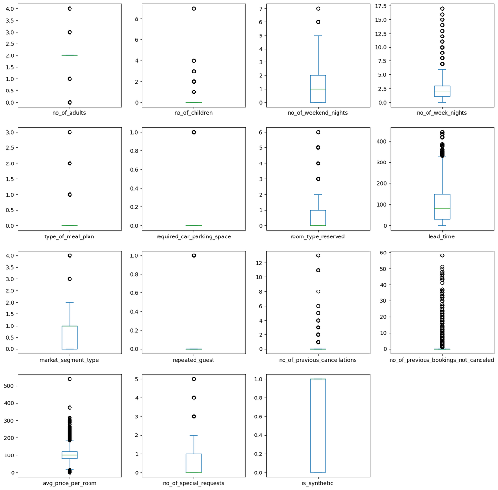

```python
# Box and Whisker plot for each attribute
df_features_train.plot(kind='box', subplots=True, layout=(display_rows, display_columns))
plt.show()
```

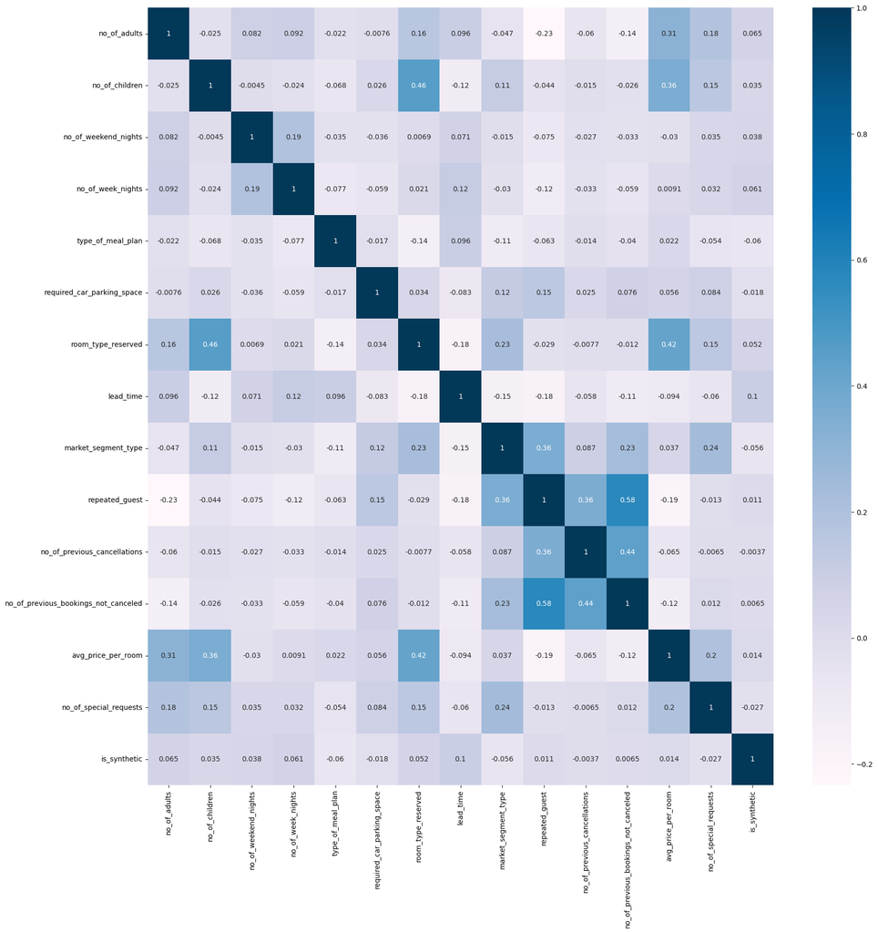

```python
# Correlation matrix
fig = plt.figure(figsize=(20, 20))
correlations = df_features_train.corr(method='pearson')
sns.heatmap(correlations, annot=True, cmap=plt.cm.PuBu)
plt.show()
```

```python
if NOTIFY_STATUS:
    status_notify("Task 2 - Summarize and Visualize Data completed! " + datetime.now().strftime('%a %B %d, %Y %I:%M:%S %p'))
```

## Task 3 - Pre-process Data

```python
if NOTIFY_STATUS:
    status_notify("Task 3 - Pre-process Data has begun! " + datetime.now().strftime('%a %B %d, %Y %I:%M:%S %p'))
```

### 3.a) Feature Scaling and Data Pre-Processing

```python
# Compose pipeline for the numerical and categorical features (Block #1 of 2)
numeric_columns = df_features_train.select_dtypes(include=['float','int']).columns
numeric_transformer = Pipeline(steps=[
    ('imputer', impute.SimpleImputer(strategy="median")),
    ('scaler', preprocessing.StandardScaler())
])
categorical_columns = df_features_train.select_dtypes(include=['object','bool','category']).columns
categorical_transformer = Pipeline(steps=[
    ('imputer', impute.SimpleImputer(strategy='constant', fill_value='UKNOWN')),
    ('onehot', preprocessing.OneHotEncoder(sparse=False, handle_unknown='ignore'))
])

print("Number of numerical columns:", len(numeric_columns))
print("Number of categorical columns:", len(categorical_columns))
print("Total number of columns in the feature dataframe:", df_features_train.shape[1])
```

```
Number of numerical columns: 15
Number of categorical columns: 0
Total number of columns in the feature dataframe: 15
```

```python
# Compose pipeline for the numerical and categorical features (Block #2 of 2)
preprocessor = compose.ColumnTransformer(transformers=[
    ('num', numeric_transformer, numeric_columns),
    ('cat', categorical_transformer, categorical_columns)
], remainder='passthrough')
```

### 3.b) Training Data Balancing

```python
# Not applicable for this iteration of modeling
```

### 3.c) Feature Selection

```python
# Not applicable for this iteration of modeling
```

### 3.d) Display the Final Datasets for Model-Building

```python
# Finalize the training dataset for the modeling activities
array_features_train = preprocessor.fit_transform(df_features_train)
array_target_train = df_target_train.to_numpy()
# label_encoder = preprocessing.LabelEncoder()
# array_target_train = label_encoder.fit_transform(df_target_train)
print("array_features_train.shape: {} array_target_train.shape: {}".format(array_features_train.shape, array_target_train.shape))
```

```
array_features_train.shape: (60237, 15) array_target_train.shape: (60237,)
```

```python
if NOTIFY_STATUS:
    status_notify("Task 3 - Pre-process Data completed! " + datetime.now().strftime('%a %B %d, %Y %I:%M:%S %p'))
```

## Task 4 - Train and Tune Models

```python
if NOTIFY_STATUS:
    status_notify("Task 4 - Train and Tune Models has begun! " + datetime.now().strftime('%a %B %d, %Y %I:%M:%S %p'))
```

### 4.a) Set test options and evaluation metric

```python
# Set up Algorithms Spot-Checking Array
start_time_training = datetime.now()
train_models = []
train_results = []
train_model_names = []
train_metrics = []
```

```python
train_models.append(('LGR', LogisticRegression(random_state=RNG_SEED, solver='lbfgs', n_jobs=N_JOBS)))
train_models.append(('CART', DecisionTreeClassifier(random_state=RNG_SEED)))
train_models.append(('KNN', KNeighborsClassifier(n_jobs=N_JOBS)))
train_models.append(('BGT', BaggingClassifier(random_state=RNG_SEED, n_jobs=N_JOBS)))
train_models.append(('RNF', RandomForestClassifier(random_state=RNG_SEED, n_jobs=N_JOBS)))
train_models.append(('EXT', ExtraTreesClassifier(random_state=RNG_SEED, n_jobs=N_JOBS)))
```

```python
# Generate model in turn
for name, model in train_models:
    if NOTIFY_STATUS:
        status_notify("Algorithm", name, "modeling has begun! " + datetime.now().strftime('%a %B %d, %Y %I:%M:%S %p'))
    start_time_module = datetime.now()
    kfold = StratifiedKFold(n_splits=N_FOLDS, shuffle=True, random_state=RNG_SEED)
    cv_results = cross_val_score(model, array_features_train, array_target_train, cv=kfold, scoring=SCORING_METRIC, n_jobs=N_JOBS, verbose=1)
    train_results.append(cv_results)
    train_model_names.append(name)
    train_metrics.append(cv_results.mean())
    print("%s: %f (%f)" % (name, cv_results.mean(), cv_results.std()))
    print(model)
    print('Model training time:', (datetime.now() - start_time_module), '\n')
    if NOTIFY_STATUS:
        status_notify("Algorithm", name, "modeling completed! " + datetime.now().strftime('%a %B %d, %Y %I:%M:%S %p'))
print('Average metrics (' + SCORING_METRIC + ') from all models:', np.mean(train_metrics))
print('Total training time for all models:', (datetime.now() - start_time_training))
```

```
[Parallel(n_jobs=2)]: Using backend LokyBackend with 2 concurrent workers.
[Parallel(n_jobs=2)]: Done  10 out of  10 | elapsed:    2.8s finished
[Parallel(n_jobs=2)]: Using backend LokyBackend with 2 concurrent workers.
```

```
LGR: 0.836402 (0.004607)
LogisticRegression(n_jobs=2, random_state=888)
Model training time: 0:00:02.947914
```

```
[Parallel(n_jobs=2)]: Done  10 out of  10 | elapsed:    1.3s finished
[Parallel(n_jobs=2)]: Using backend LokyBackend with 2 concurrent workers.
```

```
CART: 0.775775 (0.004655)
DecisionTreeClassifier(random_state=888)
Model training time: 0:00:01.421907
```

```
[Parallel(n_jobs=2)]: Done  10 out of  10 | elapsed:   13.1s finished
[Parallel(n_jobs=2)]: Using backend LokyBackend with 2 concurrent workers.
```

```
KNN: 0.850361 (0.003807)
KNeighborsClassifier(n_jobs=2)
Model training time: 0:00:13.168698
```

```
[Parallel(n_jobs=2)]: Done  10 out of  10 | elapsed:    5.5s finished
[Parallel(n_jobs=2)]: Using backend LokyBackend with 2 concurrent workers.
```

```
BGT: 0.874131 (0.006582)
BaggingClassifier(n_jobs=2, random_state=888)
Model training time: 0:00:05.599744
```

```
[Parallel(n_jobs=2)]: Done  10 out of  10 | elapsed:   20.8s finished
[Parallel(n_jobs=2)]: Using backend LokyBackend with 2 concurrent workers.
```

```
RNF: 0.888228 (0.004963)
RandomForestClassifier(n_jobs=2, random_state=888)
Model training time: 0:00:20.894115

EXT: 0.857464 (0.006126)
ExtraTreesClassifier(n_jobs=2, random_state=888)
Model training time: 0:00:20.715232

Average metrics (roc_auc) from all models: 0.8470600275052038
Total training time for all models: 0:01:04.774786
```

```
[Parallel(n_jobs=2)]: Done  10 out of  10 | elapsed:   20.6s finished
```

### 4.b) Spot-checking baseline algorithms

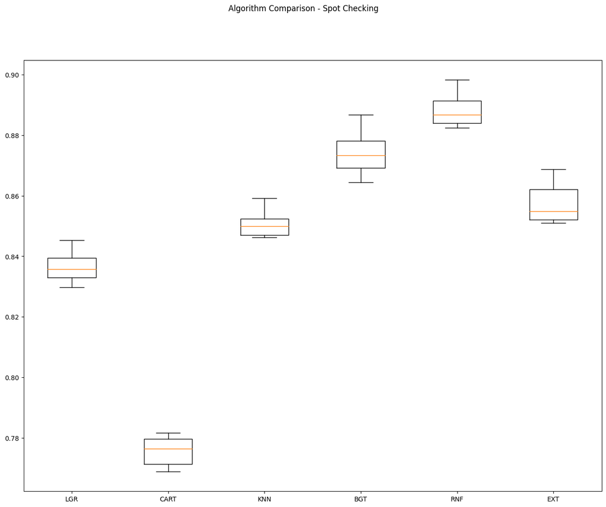

```python
fig = plt.figure(figsize=(16, 12))
fig.suptitle('Algorithm Comparison - Spot Checking')
ax = fig.add_subplot(111)
plt.boxplot(train_results)
ax.set_xticklabels(train_model_names)
plt.show()
```

```python
if NOTIFY_STATUS:
    status_notify("Task 4 - Train and Tune Models completed! " + datetime.now().strftime('%a %B %d, %Y %I:%M:%S %p'))
```

### 4.c) Algorithm Tuning

```python
# Set up the comparison array
tune_results = []
tune_model_names = []
```

```python
# Tuning algorithm #1
start_time_module = datetime.now()
if NOTIFY_STATUS:
    status_notify("Algorithm #1 tuning has begun! " + datetime.now().strftime('%a %B %d, %Y %I:%M:%S %p'))

tune_model1 = RandomForestClassifier(random_state=RNG_SEED, n_jobs=N_JOBS)
tune_model_names.append('RNF')
paramGrid1 = dict(n_estimators=np.array([100, 300, 500]))

kfold = StratifiedKFold(n_splits=N_FOLDS, shuffle=True, random_state=RNG_SEED)
grid1 = GridSearchCV(estimator=tune_model1, param_grid=paramGrid1, scoring=SCORING_METRIC, cv=kfold, n_jobs=N_JOBS, verbose=1)
grid_result1 = grid1.fit(array_features_train, array_target_train)

print("Best: %f using %s" % (grid_result1.best_score_, grid_result1.best_params_))
tune_results.append(grid_result1.cv_results_['mean_test_score'])
means = grid_result1.cv_results_['mean_test_score']
stds = grid_result1.cv_results_['std_test_score']
params = grid_result1.cv_results_['params']
for mean, stdev, param in zip(means, stds, params):
    print("%f (%f) with: %r" % (mean, stdev, param))
print('Model training time:', (datetime.now() - start_time_module))
if NOTIFY_STATUS:
    status_notify("Algorithm #1 tuning completed! " + datetime.now().strftime('%a %B %d, %Y %I:%M:%S %p'))
```

```
Fitting 10 folds for each of 3 candidates, totalling 30 fits
Best: 0.889181 using {'n_estimators': 500}
0.888228 (0.004963) with: {'n_estimators': 100}
0.888968 (0.004939) with: {'n_estimators': 300}
0.889181 (0.004877) with: {'n_estimators': 500}
Model training time: 0:03:18.777464
```

```python
best_paramKey1 = list(grid_result1.best_params_.keys())[0]
best_paramValue1 = list(grid_result1.best_params_.values())[0]
print("Captured the best parameter for algorithm #1:", best_paramKey1, '=', best_paramValue1)
```

```
Captured the best parameter for algorithm #1: n_estimators = 500
```

```python
# Tuning algorithm #2
start_time_module = datetime.now()
if NOTIFY_STATUS:
    status_notify("Algorithm #2 tuning has begun! " + datetime.now().strftime('%a %B %d, %Y %I:%M:%S %p'))

tune_model2 = BaggingClassifier(random_state=RNG_SEED, n_jobs=N_JOBS)
tune_model_names.append('BGT')
paramGrid2 = dict(n_estimators=np.array([10, 20, 30]))

kfold = StratifiedKFold(n_splits=N_FOLDS, shuffle=True, random_state=RNG_SEED)
grid2 = GridSearchCV(estimator=tune_model2, param_grid=paramGrid2, scoring=SCORING_METRIC, cv=kfold, n_jobs=N_JOBS, verbose=1)
grid_result2 = grid2.fit(array_features_train, array_target_train)

print("Best: %f using %s" % (grid_result2.best_score_, grid_result2.best_params_))
tune_results.append(grid_result2.cv_results_['mean_test_score'])
means = grid_result2.cv_results_['mean_test_score']
stds = grid_result2.cv_results_['std_test_score']
params = grid_result2.cv_results_['params']
for mean, stdev, param in zip(means, stds, params):
    print("%f (%f) with: %r" % (mean, stdev, param))
print('Model training time:', (datetime.now() - start_time_module))
if NOTIFY_STATUS:
    status_notify("Algorithm #2 tuning completed! " + datetime.now().strftime('%a %B %d, %Y %I:%M:%S %p'))
```

```
Fitting 10 folds for each of 3 candidates, totalling 30 fits
Best: 0.885041 using {'n_estimators': 30}
0.874131 (0.006582) with: {'n_estimators': 10}
0.882556 (0.005575) with: {'n_estimators': 20}
0.885041 (0.005231) with: {'n_estimators': 30}
Model training time: 0:00:34.222827
```

```python
best_paramKey2 = list(grid_result2.best_params_.keys())[0]
best_paramValue2 = list(grid_result2.best_params_.values())[0]
print("Captured the best parameter for algorithm #2:", best_paramKey2, '=', best_paramValue2)
```

```
Captured the best parameter for algorithm #2: n_estimators = 30
```

### 4.d) Compare Algorithms After Tuning

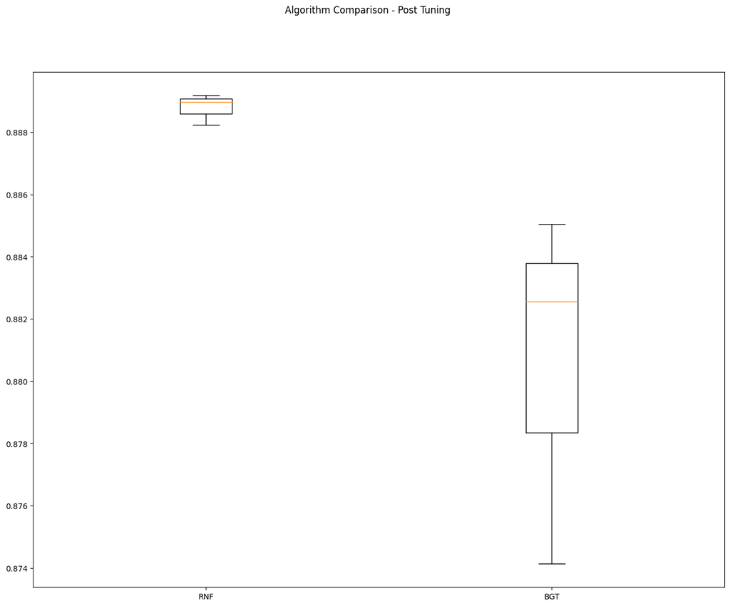

```python
fig = plt.figure(figsize=(16,12))
fig.suptitle('Algorithm Comparison - Post Tuning')
ax = fig.add_subplot(111)
plt.boxplot(tune_results)
ax.set_xticklabels(tune_model_names)
plt.show()
```

```python
if NOTIFY_STATUS:
    status_notify("Task 4 - Train and Tune Models completed! " + datetime.now().strftime('%a %B %d, %Y %I:%M:%S %p'))
```

## Task 5 - Finalize Model and Make Predictions

```python
if NOTIFY_STATUS:
    status_notify("Task 5 - Finalize Model and Make Predictions has begun! " + datetime.now().strftime('%a %B %d, %Y %I:%M:%S %p'))
```

### 5.a) Train the Final Model

```python
final_model = RandomForestClassifier(n_estimators=best_paramValue1, random_state=RNG_SEED, n_jobs=N_JOBS)
final_model.fit(array_features_train, array_target_train)
print(final_model)
```

```
RandomForestClassifier(n_estimators=500, n_jobs=2, random_state=888)
```

### 5.b) Load Test Dataset and Make Predictions

```python
df_features_test = pd.read_csv(TEST_DATASET)
df_features_test['is_synthetic'] = 1
df_features_test.drop(columns=['arrival_year', 'arrival_month',
                               'arrival_date'], inplace=True)

df_features_test.info(verbose=True)
```

```
<class 'pandas.core.frame.DataFrame'>
RangeIndex: 28068 entries, 0 to 28067
Data columns (total 16 columns):
 #   Column                                Non-Null Count  Dtype
---  ------                                --------------  -----
 0   id                                    28068 non-null  int64
 1   no_of_adults                          28068 non-null  int64
 2   no_of_children                        28068 non-null  int64
 3   no_of_weekend_nights                  28068 non-null  int64
 4   no_of_week_nights                     28068 non-null  int64
 5   type_of_meal_plan                     28068 non-null  int64
 6   required_car_parking_space            28068 non-null  int64
 7   room_type_reserved                    28068 non-null  int64
 8   lead_time                             28068 non-null  int64
 9   market_segment_type                   28068 non-null  int64
 10  repeated_guest                        28068 non-null  int64
 11  no_of_previous_cancellations          28068 non-null  int64
 12  no_of_previous_bookings_not_canceled  28068 non-null  int64
 13  avg_price_per_room                    28068 non-null  float64
 14  no_of_special_requests                28068 non-null  int64
 15  is_synthetic                          28068 non-null  int64
dtypes: float64(1), int64(15)
memory usage: 3.4 MB
```

```python
id_column_name = df_features_test.columns[0]
df_kaggle_submission = pd.DataFrame()
df_kaggle_submission[id_column_name] = df_features_test[id_column_name]
print(df_kaggle_submission.head())
```

```
      id
0  42100
1  42101
2  42102
3  42103
4  42104
```

```python
# Dropping unique identifier and unnecessary features
df_features_test.drop(columns=[id_column_name], inplace=True)

# Take a peek at the dataframe after cleaning
print(df_features_test.head())
```

```
   no_of_adults  no_of_children  no_of_weekend_nights  no_of_week_nights  \
0             3               0                     1                  4
1             2               0                     0                  3
2             2               2                     0                  1
3             2               0                     0                  3
4             1               0                     0                  2

   type_of_meal_plan  required_car_parking_space  room_type_reserved  \
0                  0                           0                   1
1                  0                           0                   0
2                  0                           0                   3
3                  0                           0                   0
4                  2                           0                   0

   lead_time  market_segment_type  repeated_guest  \
```

[output cut: 19 more lines]

```python
# Finalize the test dataset for the testing activities
array_features_test = preprocessor.transform(df_features_test)
print("Transformed features from df_features_test.shape: {} to array_features_test.shape: {}".format(df_features_test.shape, array_features_test.shape))
```

```
Transformed features from df_features_test.shape: (28068, 15) to array_features_test.shape: (28068, 15)
```

```python
# Make batched predictions
test_predictions = final_model.predict_proba(array_features_test)
print(test_predictions)
```

```
[[0.926      0.074     ]
 [0.688      0.312     ]
 [0.5185     0.4815    ]
 ...
 [1.         0.        ]
 [0.19983333 0.80016667]
 [0.03891667 0.96108333]]
```

```python
df_sample_submission = pd.read_csv(SUBMISSION_TEMPLATE)
df_sample_submission.drop(columns=[id_column_name], inplace=True)
submission_header = list(df_sample_submission.columns)[0]
print(submission_header)
```

```
booking_status
```

```python
df_kaggle_submission[submission_header] = test_predictions[:,1]
print(df_kaggle_submission.head())
```

```
      id  booking_status
0  42100        0.074000
1  42101        0.312000
2  42102        0.481500
3  42103        0.002000
4  42104        0.321667
```

```python
submission_file = df_kaggle_submission.to_csv(header=True, index=False)
filename = SUBMISSION_FILE + datetime.now().strftime('%Y%m%d-%H%M') + '.csv'
with open(filename, 'w') as f:
    f.write(submission_file)
    print('Completed writing output file: ' + filename)
```

```
Completed writing output file: submission_sklearn_20230320-1807.csv
```

```python
if NOTIFY_STATUS:
    status_notify("Task 5 - Finalize Model and Make Predictions completed! " + datetime.now().strftime('%a %B %d, %Y %I:%M:%S %p'))
```

```python
print('Total time for the script:', (datetime.now() - START_TIME_SCRIPT))
```

```
Total time for the script: 0:05:20.314950
```